# Exercise 3_1: Subsetting Raster Data

Advanced Geospatial Data Processing for Social Scientists

Author

Dennis Abel & Stefan Jünger

In the following two exercises, you’ll practice editing raster data and visualizing it clearly and creatively. You’ll learn how to cut rasters based on administrative boundaries, combine multiple rasters into one view, and explore how to style maps with simple but powerful base R tools.

These are essential steps when preparing geospatial data for analysis and presentation — and a great chance to apply everything you’ve learned so far!

### Exercises

**Note🏋️ Exercise 1**

Choose a raster `.tif` layer from the `./data/z22/` folder. (Not sure what a file contains? File names match Census variable names — check the [Census 2022 database](https://ergebnisse.zensus2022.de/datenbank/online/themes) for descriptions.)

Your task is to split the raster into two parts: one for the northern and one for the southern part of Germany!

Use the shapefile `VG250_LAN.shp` (located in `./data/boundaries/`) to help define the boundaries: This shapefile contains the outlines of Germany’s federal states (Bundesländer).

**Caution💡 Tip**

- Load the shapefile with `sf::st_read()`.
- Use the attribute table to find which states are in the north and which are in the south.
- You can create subsets of the polygons based on the “GEN” column.
- To cut the raster, you can use `terra::crop()`, `terra::mask()` or both combined with your north/south polygons.

You can split the federal states into “North” and “South” — but keep in mind, some states are geographically in between (“gray zone”). Here’s a rough guide:

Northern Germany (examples):

- Schleswig-Holstein
- Hamburg
- Bremen
- Lower Saxony (Niedersachsen)
- Mecklenburg-Vorpommern
- Brandenburg
- Berlin

Southern Germany (examples):

- Bavaria (Bayern)
- Baden-Württemberg
- Saarland
- Rhineland-Palatinate (Rheinland-Pfalz)

Gray zone (in between North and South):

- North Rhine-Westphalia (Nordrhein-Westfalen)
- Hesse (Hessen)
- Saxony (Sachsen)
- Saxony-Anhalt (Sachsen-Anhalt)
- Thuringia (Thüringen)

Feel free to decide for yourself how you classify the “gray zone” states! Your definition is part of the creative freedom in this exercise.

**Note🏋️ Exercise 2**

Now that you’ve split the raster into Northern and Southern Germany, let’s visualize and compare your results!

- Create one map showing the northern raster and one showing the southern raster.
- Use `terra::global()` to calculate the mean value for each part. Which region has higher values? Does the result surprise you, given what you know about the variable you chose?
- Bonus: Combine both rasters on one map, using different color palettes to highlight the difference!

**Caution💡 Tip**

- Use `plot()` for each raster.
- `terra::global(raster, fun = "mean", na.rm = TRUE)` gives you summary statistics.
- To combine them, first plot one raster, then add the second one with `add = TRUE`.
- You can adjust the color palettes with the `col` argument (e.g., `terrain.colors()`, `heat.colors()`).

Example palettes you might try:

- North: `terrain.colors(20)`
- South: `heat.colors(20)`

### Solutions

**Tip✅ Solution 1**

```r
library(sf)
library(terra)
# Load a raster layer of your choice from the Census data
age_avg <- terra::rast("./data/z22/age_avg.tif")

# Load the federal states shapefile (contains state names in "GEN" column)
states <- sf::st_read("./data/boundaries/VG250_LAN.shp", quiet = TRUE) |>
  sf::st_transform(3035)

# Subset the states into north and south
# Note: The "gray zone" states (NRW, Hessen, etc.) are assigned here —
# your classification may differ, and that's fine!
north_states <-
  states |>
  dplyr::filter(
    GEN %in% c(
      "Schleswig-Holstein", "Hamburg", "Bremen", "Niedersachsen",
      "Mecklenburg-Vorpommern", "Brandenburg", "Berlin",
      "Nordrhein-Westfalen", "Sachsen-Anhalt"
    )
  )

south_states <-
  states |>
  dplyr::filter(
    GEN %in% c(
      "Bayern", "Baden-Württemberg", "Saarland",
      "Rheinland-Pfalz", "Hessen", "Sachsen", "Thüringen"
    )
  )

# Cut the raster: mask sets values outside the boundary to NA,
# crop trims the extent so we don't carry around a huge grid
age_north <-
  terra::mask(age_avg, north_states) |>
  terra::crop(north_states)

age_south <-
  terra::mask(age_avg, south_states) |>
  terra::crop(south_states)
```

**Tip✅ Solution 2**

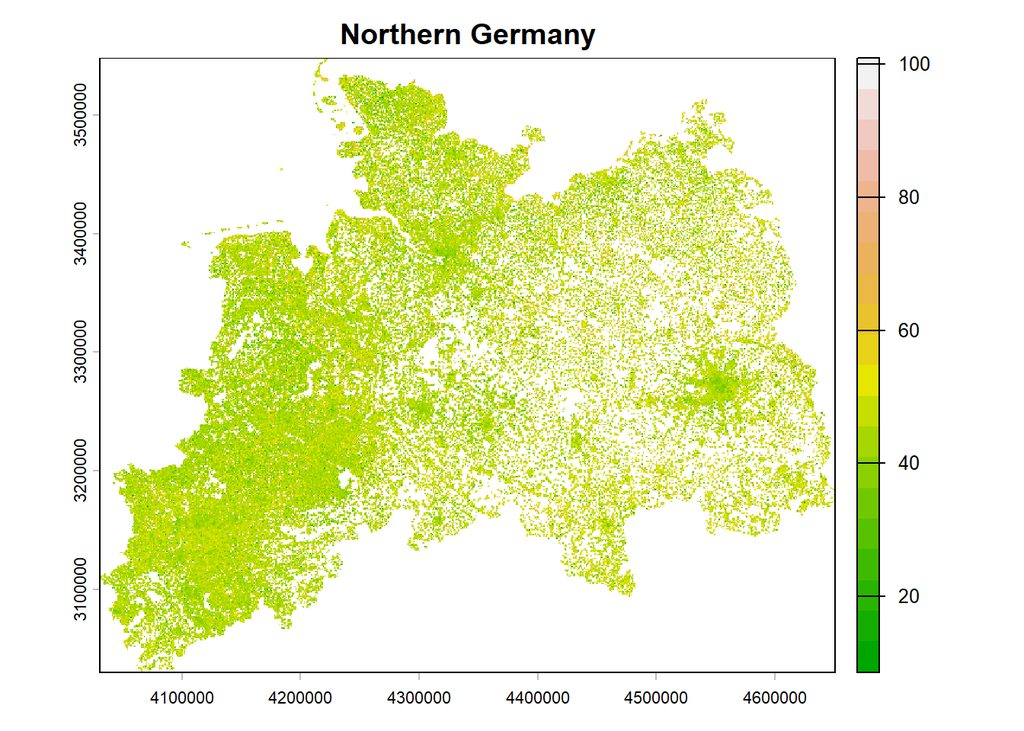

```r
# Individual maps with different color palettes
plot(age_north, main = "Northern Germany", col = terrain.colors(20))
```

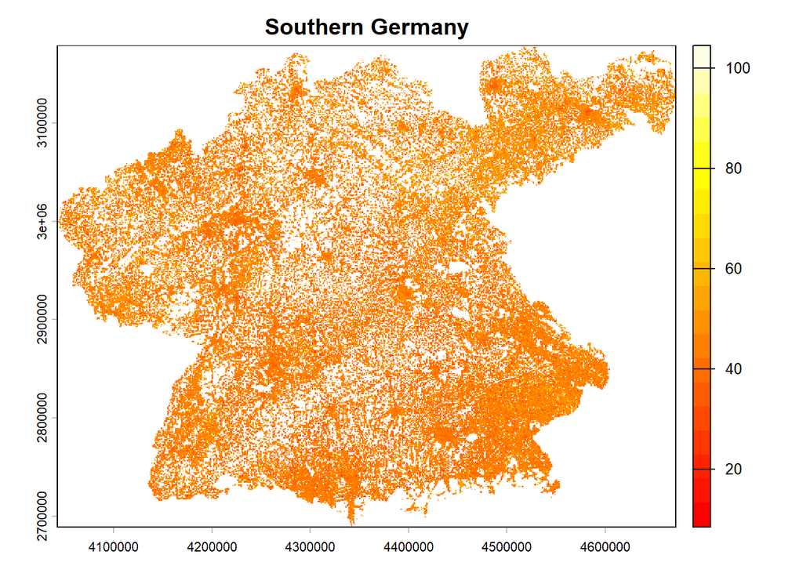

```r
plot(age_south, main = "Southern Germany", col = heat.colors(20))
```

```r
# Compare mean values — is the north older or younger than the south?
# global() computes a summary statistic across the entire raster
terra::global(age_north, fun = "mean", na.rm = TRUE)
```

```
          mean
cat_0 46.57203
```

```r
terra::global(age_south, fun = "mean", na.rm = TRUE)
```

```
          mean
cat_0 45.47058
```

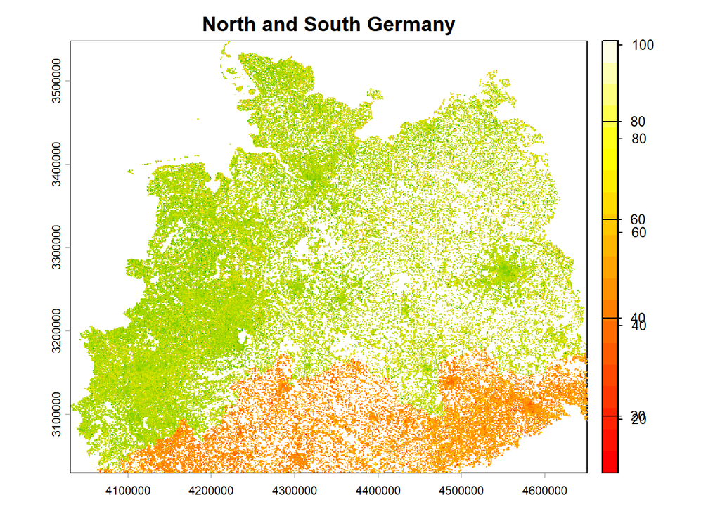

```r
# Bonus: combine both on one map
# Plot the first raster, then overlay the second with add = TRUE
plot(age_north, main = "North and South Germany", col = terrain.colors(20))
plot(age_south, add = TRUE, col = heat.colors(20))
```